# Module 3: Collaborative Exercise

Author

Emil Joson, Talia Swanson

*In this week’s exercise, we practiced cleaning data, looking them over through exploratory figures, and doing so with a collaborator through GitHub.*

# 1 Methods

## 1.1 Data

Initial data and scripts templates used for this exercise were provided from https://github.com/ahgroup/data-analysis-template. Original data only included Height, Weight, and Gender - Hotdogs and Shirt were added for this exercise.

## 1.2 Data Cleanup

Data was visually inspected for anomalies and then subsequently corrected. Corrections include ensuring data types were consistent within each variable, removing potentially incorrect data entries (i.e. individual with weight of 7000), and correcting potentially incorrectly input data (i.e. converting input height of 6 to 182.88 centimeters).

## 1.3 Statistical analysis

Associations between the variables were assessed using linear regression models (*lm*).

# 2 Results

## 2.1 Data Summary

The data used in this exercise contained five variables: Height, Weight, Gender, Hotdogs, Shirt - with the former three being part of the original dataset and the latter two added for this exercise. The variables Height, Weight, and Hotdogs are numerical while the variables Gender and Shirt are categorical (Height is reported in centimeters; Weight is reported in kilograms; Gender is reported in M (male), F (female), or O (other); Hotdogs is reported as the number of hotdogs the individual can consume; Shirt is reported in shirt sizes S, M, L, XL.) Summary of the data is provided in Table 1.

Table 1: Summary table of the data used in the exercise.

| skim_type | skim_variable | n_missing | complete_rate | character.min | character.max | character.empty | character.n_unique | character.whitespace | factor.ordered | factor.n_unique | factor.top_counts | numeric.mean | numeric.sd | numeric.p0 | numeric.p25 | numeric.p50 | numeric.p75 | numeric.p100 | numeric.hist |
| --- | --- | --- | --- | --- | --- | --- | --- | --- | --- | --- | --- | --- | --- | --- | --- | --- | --- | --- | --- |
| character | Shirt | 0 | 1 | 1 | 2 | 0 | 4 | 0 | NA | NA | NA | NA | NA | NA | NA | NA | NA | NA | NA |
| factor | Gender | 0 | 1 | NA | NA | NA | NA | NA | FALSE | 3 | M: 4, F: 3, O: 2 | NA | NA | NA | NA | NA | NA | NA | NA |
| numeric | Height | 0 | 1 | NA | NA | NA | NA | NA | NA | NA | NA | 165.66667 | 15.976545 | 133 | 156 | 166 | 178 | 183 | ▂▁▃▃▇ |
| numeric | Weight | 0 | 1 | NA | NA | NA | NA | NA | NA | NA | NA | 70.11111 | 21.245261 | 45 | 55 | 70 | 80 | 110 | ▇▂▃▂▂ |
| numeric | Hotdogs | 0 | 1 | NA | NA | NA | NA | NA | NA | NA | NA | 12.11111 | 9.778093 | 3 | 4 | 9 | 18 | 29 | ▇▃▂▁▃ |

## 2.2 Height

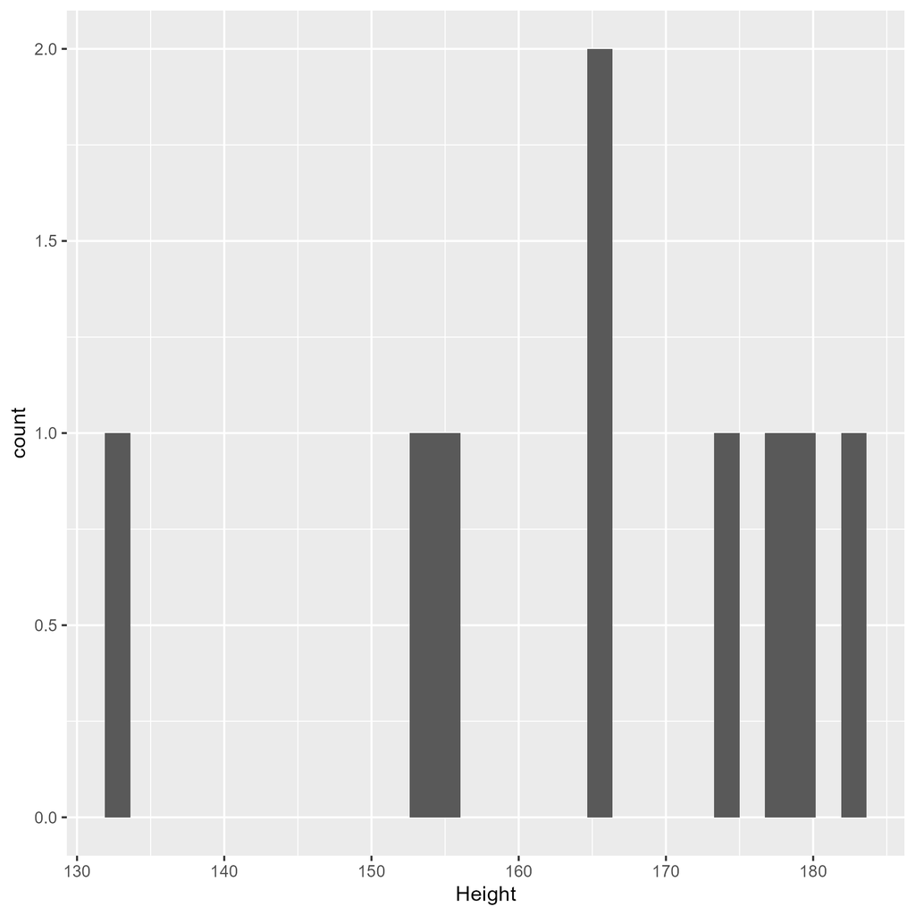

Figure 1. Height (cm) distribution of respondents.

## 2.3 Weight

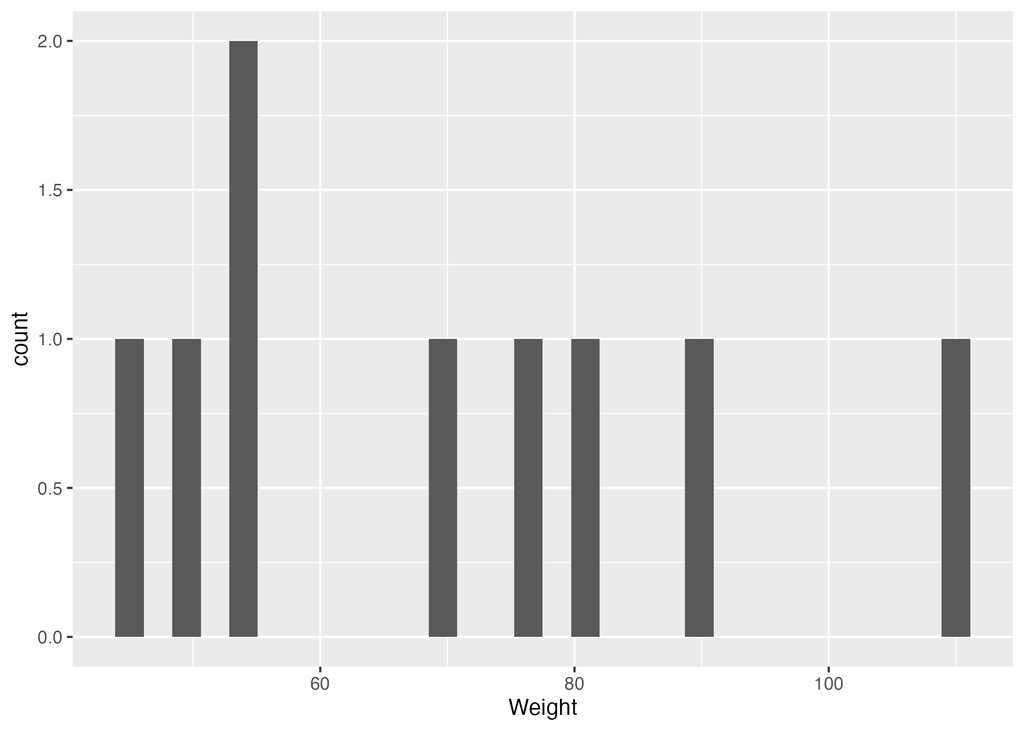

Figure 2. Weight (kg) distribution of respondents.

# 3 Analysis

## 3.1 Height vs Weight

Investigating height and weight did not reveal a significant association (*P* = 0.43) (Fig. 3).

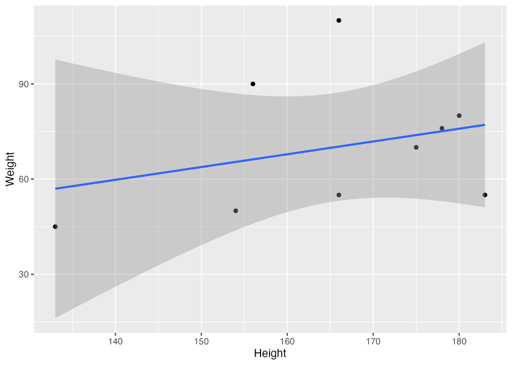

Figure 3. Scatterplot showing the relationship between height and weight with a fitted linear regression line.

Even when including Gender as a predictor (Fig. 4), significant assocaitions were still not observed.

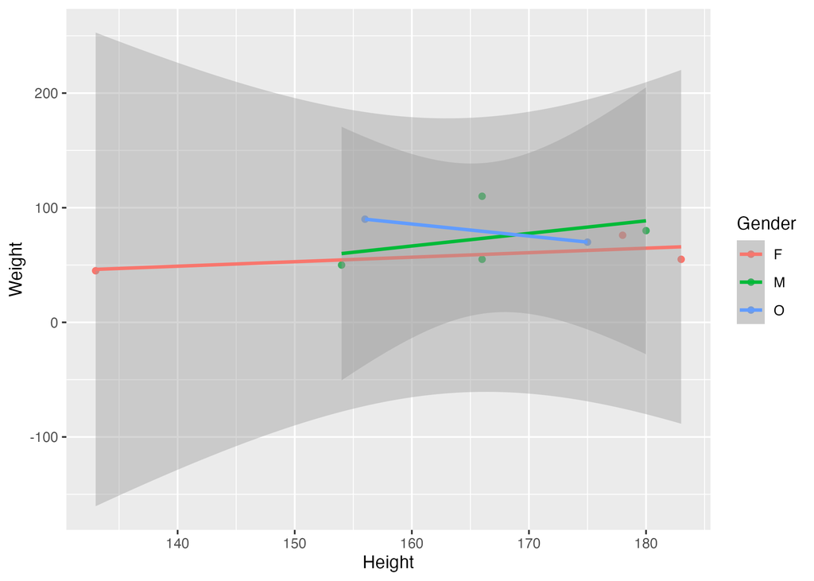

Figure 1: Figure 4. Scatterplot of height versus weight with points colored by gender. The solid line represents the fitted multiple linear regression model.

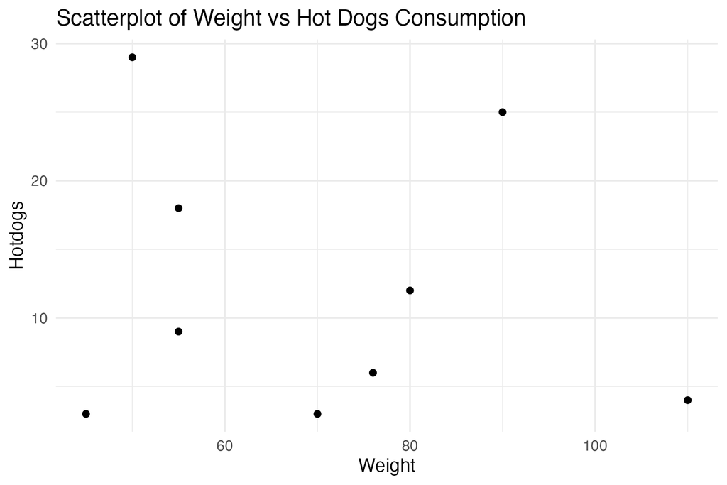

Figure 5. Scatterplot showing the relationship between hotdogs and weight.